# Welcome to Safran TP 1

Every day, more than 80,000 commercial flights take place around the world, operated by hundreds of airlines. For all aircraft take-off weight exceeding 27 tons, a regulatory constraint requires companies to systematically record and analyse all flight data, for the purpose of improving the safety of flights. Flight Data Monitoring strives to detect and prioritize deviations from standards set by the aircraft manufacturers, the authorities of civil aviation in the country, or even companies themselves. Such deviations, called events, are used to populate a database that enables companies to identify and monitor the risks inherent to these operations.

This notebook is designed to let you manipulate real aeronautical data, provided by the Safran Group. It is divided in two parts: the first part deals with the processing of raw data, you will be asked to visualize the data, understand what variables require processing and perform the processing for some of these variables. The second part deals with actual data analysis, and covers some interesting problems. We hope to give you some insights of the data scientist job and give you interesting and challenging questions.

# Part 1: Data processing

## Loading the data

Load the **raw** data into the structure proposed below (the schema is given to you), using the code provided. The definition of the variables available is given here:

| var | description |
| --- | --- |
| TIME | elapsed seconds |
| LATP_1 | Latitude (°) |
| LONP_1 | Longitude (°) |
| RALT1 | Radio Altitude, sensor 1 (feet) |
| RALT2 | Radio Altitude, sensor 2 (feet) |
| RALT3 | Radio Altitude, sensor 3 (feet) |
| ALT_STD | Relative Altitude (feet) |
| HEAD | head (°) |
| PITCH | pitch (°) |
| ROLL | roll (°) |
| IAS | Indicated Air Speed (m/s) |
| N11 | speed N1 of the first engine (% of tr/min) |
| N21 | speed N2 of the first engine (% of tr/min) |
| N12 | speed N1 of the second engine (% of tr/min) |
| N22 | speed N2 of the second engine (% of tr/min) |
| AIR_GROUND | boolean, 0: ground, 1: air |

The sample rate is 1 Hz. You will be provided with `780` flight records. Each is a full record of a flight starting at the beginning of the taxi out phase and terminating at the end of the taxi in phase. Please be aware that due to side effects the very beginning of the record may be faulty. This is something to keep in mind when we will analyse the data.

**Note** : `TIME` represents the elapsed seconds from today midnight. You are not provided with an absolute time variable that would tell you the date and hour of the flights.

You will need some expertise about the signification of the variables. Latitude and longitude are quite straightforward. Head, Pitch and Roll are standards orientation angles, check this [image](https://i.stack.imgur.com/65EKz.png) to be sure. RALT* are coming from three different radio altimeters, they measure the same thing but have a lot of missing values and are valid only under a threshold altitude (around 5000 feet). Alt_std is the altitude measured from the pressure (it basically comes from a barometer), it is way less accurate that a radio altimeter but provides values for all altitudes. N1* and N2* are the rotational speeds of the engine sections expressed as a percentage of a nominal value. Some good links to check out to go deeper:

- [about phases of flight](http://www.fp7-restarts.eu/index.php/home/root/state-of-the-art/objectives/2012-02-15-11-58-37/71-book-video/parti-principles-of-flight/126-4-phases-of-a-flight)
- [pitch-roll-head](https://i.stack.imgur.com/65EKz.png)
- [about N** variables I](http://aviation.stackexchange.com/questions/14690/what-are-n1-and-n2)
- [about N** variables II](https://www.quora.com/Whats-N1-N2-in-aviation-And-how-is-the-value-of-100-N1-N2-determined)
- [how altimeters work](http://www.explainthatstuff.com/how-altimeters-work.html)
- [about runway naming](https://en.wikipedia.org/wiki/Runway#Naming)

```python
BASE_DIR = "/mnt/datasets/SAFRAN/data/"

from os import listdir
from os.path import isfile, join

import glob

import matplotlib as mpl
mpl.rcParams["axes.grid"] = True
import matplotlib.pylab as plt
%matplotlib inline

import numpy as np
import pandas as pd
pd.options.display.max_columns = 50

from datetime import datetime

# from haversine import haversine

def load_data_from_directory(DATA_PATH, num_flights):
    files_list = glob.glob(join(DATA_PATH, "*pkl"))
    print("There are %d files in total" % len(files_list))
    files_list = files_list[:num_flights]
    print("We process %d files" % num_flights)
    dfs = []
    p = 0
    for idx, f in enumerate(files_list):
        if idx % int(len(files_list)/10) == 0:
            print(str(p*10) + "%: [" + "#"*p + " "*(10-p) + "]", end="\r")
            p += 1
        dfs.append(pd.read_pickle(f))
    print(str(p*10) + "%: [" + "#"*p + " "*(10-p) + "]", end="\r")
    return dfs

# from IPython.core.display import HTML
# css = open('style-table.css').read()
# HTML('<style>{}</style>'.format(css))
```

Execute the cell below to load the data for part 1

```python
num_flights = 780
flights1 = load_data_from_directory(BASE_DIR + "part1/flights", num_flights)
for f in flights1:
    l = len(f)
    new_idx = pd.date_range(start=pd.Timestamp("now").date(), periods=l, freq="S")
    f.set_index(new_idx, inplace=True)
```

```
There are 780 files in total
We process 780 files
```

The data is loaded with pandas. Please take a look at the [pandas cheat sheet](https://github.com/pandas-dev/pandas/blob/master/doc/cheatsheet/Pandas_Cheat_Sheet.pdf) if you have any doubt. You are provided with 780 dataframes, each of them represents the records of the variables defined above during a whole flight.

`flights1` is a list where each item is a dataframe storing the data of one flight. There is no particular ordering in this list. All the flights depart from the same airport and arrive at the same airport. These airports are hidden to you and you will soon understand how.

For example `flights1[0]` is a dataframe, representing one flight.

```python
flights1[0].head(20)
```

|  | TIME | LATP_1 | LONP_1 | HEAD | PITCH | ROLL | IAS | RALT1 | RALT2 | RALT3 | ALT_STD | N11 | N21 | N22 | N12 | AIR_GROUND |
| --- | --- | --- | --- | --- | --- | --- | --- | --- | --- | --- | --- | --- | --- | --- | --- | --- |
| 2018-05-25 00:00:00 | 0 | 11.7731 | 33.3118 | 350.5 | -0.9 | -1.0 | 45.0 | NaN | NaN | -4.0 | -83.0 | 2.0 | 22.63 | 59.50 | 19.63 | 1.0 |
| 2018-05-25 00:00:01 | 1 | 11.7731 | 33.3118 | 350.5 | -0.9 | -1.0 | 45.0 | -4.0 | NaN | NaN | -83.0 | 2.0 | 23.75 | 59.38 | 19.75 | 1.0 |
| 2018-05-25 00:00:02 | 2 | 50.7330 | 21.2602 | 350.5 | -0.9 | -1.0 | 45.0 | NaN | NaN | -4.0 | -83.0 | 2.0 | 24.75 | 59.38 | 19.88 | 1.0 |
| 2018-05-25 00:00:03 | 3 | 48.0318 | 12.5277 | 350.1 | -0.9 | -1.0 | 45.0 | NaN | -5.0 | NaN | -84.0 | 3.0 | 25.63 | 59.50 | 20.00 | 1.0 |
| 2018-05-25 00:00:04 | 4 | 48.0318 | 12.5277 | 350.1 | -0.9 | -1.0 | 45.0 | NaN | NaN | -4.0 | -83.0 | 3.0 | 26.50 | 59.50 | 20.25 | 1.0 |
| 2018-05-25 00:00:05 | 5 | 48.0318 | 12.5277 | 349.8 | -0.9 | -1.0 | 45.0 | -4.0 | NaN | NaN | -84.0 | 3.0 | 27.13 | 59.38 | 20.50 | 1.0 |
| 2018-05-25 00:00:06 | 6 | 48.0318 | 12.5277 | 349.4 | -0.9 | -1.0 | 45.0 | NaN | NaN | -4.0 | -83.0 | 4.0 | 28.88 | 59.38 | 20.75 | 1.0 |
| 2018-05-25 00:00:07 | 7 | 48.0318 | 12.5277 | 349.4 | -0.9 | -1.0 | 45.0 | NaN | -5.0 | NaN | -82.0 | 5.0 | 30.50 | 59.38 | 20.63 | 1.0 |
| 2018-05-25 00:00:08 | 8 | 48.0318 | 12.5277 | 349.1 | -0.9 | -1.0 | 45.0 | NaN | NaN | -4.0 | -82.0 | 6.0 | 32.25 | 59.38 | 20.50 | 1.0 |
| 2018-05-25 00:00:09 | 9 | 48.0318 | 12.5277 | 349.4 | -0.9 | -1.0 | 45.0 | -4.0 | NaN | NaN | -82.0 | 6.0 | 34.00 | 59.38 | 20.38 | 1.0 |
| 2018-05-25 00:00:10 | 10 | 48.0316 | 12.5278 | 349.4 | -0.9 | -1.0 | 45.0 | NaN | NaN | -4.0 | -81.0 | 7.0 | 35.75 | 59.38 | 20.13 | 1.0 |
| 2018-05-25 00:00:11 | 11 | 48.0316 | 12.5278 | 349.8 | -0.9 | -1.0 | 45.0 | NaN | -5.0 | NaN | -82.0 | 8.0 | 37.38 | 59.38 | 20.00 | 1.0 |
| 2018-05-25 00:00:12 | 12 | 48.0316 | 12.5278 | 349.8 | -0.9 | -1.0 | 45.0 | NaN | NaN | -4.0 | -82.0 | 9.0 | 39.13 | 59.50 | 19.88 | 1.0 |
| 2018-05-25 00:00:13 | 13 | 48.0316 | 12.5278 | 349.8 | -0.9 | -1.0 | 45.0 | -4.0 | NaN | NaN | -82.0 | 10.0 | 40.88 | 59.38 | 19.50 | 1.0 |
| 2018-05-25 00:00:14 | 14 | 48.0316 | 12.5278 | 350.1 | -0.9 | -1.0 | 45.0 | NaN | NaN | -4.0 | -82.0 | 11.0 | 42.63 | 59.50 | 19.38 | 1.0 |
| 2018-05-25 00:00:15 | 15 | 48.0316 | 12.5278 | 350.5 | -0.9 | -1.0 | 45.0 | NaN | -4.0 | NaN | -82.0 | 12.0 | 44.50 | 59.50 | 19.38 | 1.0 |
| 2018-05-25 00:00:16 | 16 | 48.0316 | 12.5278 | 350.8 | -0.9 | -1.0 | 45.0 | NaN | NaN | -4.0 | -81.0 | 13.0 | 46.25 | 59.50 | 19.38 | 1.0 |
| 2018-05-25 00:00:17 | 17 | 48.0316 | 12.5280 | 351.5 | -0.9 | -1.0 | 45.0 | -4.0 | NaN | NaN | -82.0 | 14.0 | 48.00 | 59.50 | 19.38 | 1.0 |
| 2018-05-25 00:00:18 | 18 | 48.0316 | 12.5280 | 351.9 | -0.9 | -1.0 | 45.0 | NaN | NaN | -4.0 | -83.0 | 15.0 | 50.00 | 59.50 | 19.25 | 1.0 |
| 2018-05-25 00:00:19 | 19 | 48.0316 | 12.5280 | 352.2 | -0.9 | -1.0 | 45.0 | NaN | -4.0 | NaN | -83.0 | 16.0 | 51.88 | 59.38 | 19.38 | 1.0 |

You can select a column by indexing by its name.

```python
flights1[0]["PITCH"].describe()
```

```
count    7704.000000
mean        2.005101
std         2.378875
min        -2.800000
25%         0.500000
50%         1.800000
75%         2.800000
max        16.000000
Name: PITCH, dtype: float64
```

Use `iloc[]` to select by line number, either the whole dataframe to obtain all the variables or an individual series.

```python
flights1[0].iloc[50:60]
```

|  | TIME | LATP_1 | LONP_1 | HEAD | PITCH | ROLL | IAS | RALT1 | RALT2 | RALT3 | ALT_STD | N11 | N21 | N22 | N12 | AIR_GROUND |
| --- | --- | --- | --- | --- | --- | --- | --- | --- | --- | --- | --- | --- | --- | --- | --- | --- |
| 2018-05-25 00:00:50 | 50 | 48.0314 | 12.5278 | 352.9 | -0.9 | -1.0 | 45.0 | NaN | NaN | -4.0 | -82.0 | 20.0 | 59.38 | 59.25 | 19.63 | 1.0 |
| 2018-05-25 00:00:51 | 51 | 48.0314 | 12.5278 | 352.9 | -0.9 | -1.0 | 45.0 | NaN | -5.0 | NaN | -81.0 | 20.0 | 59.50 | 59.38 | 19.50 | 1.0 |
| 2018-05-25 00:00:52 | 52 | 48.0314 | 12.5278 | 352.9 | -0.9 | -1.0 | 45.0 | NaN | NaN | -4.0 | -81.0 | 19.0 | 59.50 | 59.38 | 19.50 | 1.0 |
| 2018-05-25 00:00:53 | 53 | 48.0314 | 12.5278 | 352.9 | -0.9 | -1.0 | 45.0 | -4.0 | NaN | NaN | -81.0 | 19.0 | 59.50 | 59.38 | 19.50 | 1.0 |
| 2018-05-25 00:00:54 | 54 | 48.0314 | 12.5278 | 352.9 | -0.9 | -1.0 | 45.0 | NaN | NaN | -4.0 | -81.0 | 20.0 | 59.50 | 59.38 | 19.50 | 1.0 |
| 2018-05-25 00:00:55 | 55 | 48.0314 | 12.5278 | 352.9 | -0.9 | -1.0 | 45.0 | NaN | -5.0 | NaN | -81.0 | 20.0 | 59.50 | 59.38 | 19.50 | 1.0 |
| 2018-05-25 00:00:56 | 56 | 48.0314 | 12.5278 | 352.9 | -0.9 | -1.0 | 45.0 | NaN | NaN | -4.0 | -81.0 | 20.0 | 59.50 | 59.38 | 19.63 | 1.0 |
| 2018-05-25 00:00:57 | 57 | 48.0316 | 12.5278 | 352.9 | -0.9 | -1.0 | 45.0 | -4.0 | NaN | NaN | -81.0 | 20.0 | 59.50 | 59.38 | 19.75 | 1.0 |
| 2018-05-25 00:00:58 | 58 | 48.0316 | 12.5278 | 352.9 | -0.9 | -1.0 | 45.0 | NaN | NaN | -4.0 | -81.0 | 20.0 | 59.50 | 59.38 | 19.75 | 1.0 |
| 2018-05-25 00:00:59 | 59 | 48.0316 | 12.5278 | 352.9 | -0.9 | -1.0 | 45.0 | NaN | -5.0 | NaN | -82.0 | 20.0 | 59.50 | 59.38 | 19.75 | 1.0 |

```python
flights1[0]["PITCH"].iloc[50:60]
```

```
2018-05-25 00:00:50   -0.9
2018-05-25 00:00:51   -0.9
2018-05-25 00:00:52   -0.9
2018-05-25 00:00:53   -0.9
2018-05-25 00:00:54   -0.9
2018-05-25 00:00:55   -0.9
2018-05-25 00:00:56   -0.9
2018-05-25 00:00:57   -0.9
2018-05-25 00:00:58   -0.9
2018-05-25 00:00:59   -0.9
Freq: S, Name: PITCH, dtype: float64
```

## Visualization

To perform monitoring of flights, it is necessary to clean up the data. To start, it is important to visualize the data that is available, in order to understand better their properties and the problems associated with them (noise, statistical characteristics, ladders, features and other values).

### Question 1 Visualize all the variables

For an arbitrary flight, for example `flights1[0]`, visualize all the variables. Would you rather use plot or scatter? Interpolate the data or not interpolate? Think about NaN values and how they are treated when we plot a series. Comment.

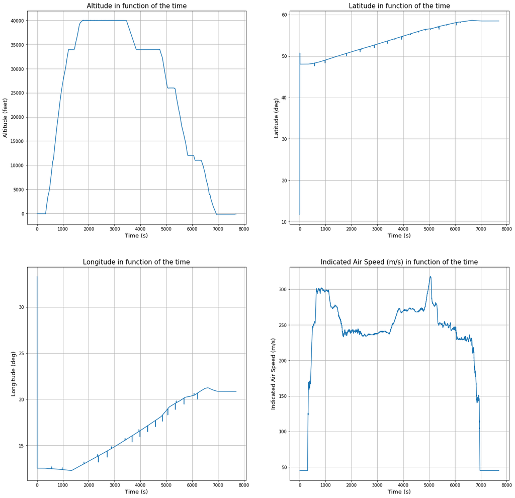

```python
f = plt.figure(figsize=(20,20))
ax1 = f.add_subplot(2,2,1)
ax1.plot(flights1[0]['TIME'], flights1[0]['ALT_STD'])
plt.title("Altitude in function of the time",fontsize=15)
plt.xlabel('Time (s)', fontsize = 13)
plt.ylabel('Altitude (feet)', fontsize = 13)
ax1 = f.add_subplot(2,2,2)
ax1.plot(flights1[0]['TIME'], flights1[0]['LATP_1'])
plt.title("Latitude in function of the time",fontsize=15)
plt.xlabel('Time (s)', fontsize = 13)
plt.ylabel('Latitude (deg)', fontsize = 13)
ax1 = f.add_subplot(2,2,3)
ax1.plot(flights1[0]['TIME'], flights1[0]['LONP_1'])
plt.title("Longitude in function of the time",fontsize=15)
plt.xlabel('Time (s)', fontsize = 13)
plt.ylabel('Longitude (deg)', fontsize = 13)
ax1 = f.add_subplot(2,2,4)
ax1.plot(flights1[0]['TIME'], flights1[0]['IAS'])
plt.title("Indicated Air Speed (m/s) in function of the time",fontsize=15)
plt.xlabel('Time (s)', fontsize = 13)
plt.ylabel('Indicated Air Speed (m/s)', fontsize = 13)
plt.show()
```

Our first graph displays the altitude as a function of time. We were expecting this shape, with a strong increase when taking off and climbing, and a much smoother slope when going down to prepare for landing (with steps).

Then, we have the latitude and the longitude as functions of time. We can see that there are several errors (with several points that indicate unexpected value jumps). We can moreover see that the first few points are wrong, as the text was indicating at the beginning. We will try to take these points out later on.

Finally, we display the IAS as a function of time. We have a great increase in speed at the beginning when taking off, then some various values when cruising. We finally have slight decreases in speed when descending for landing (and we can observe the same 'steps' that we had for the altitude).

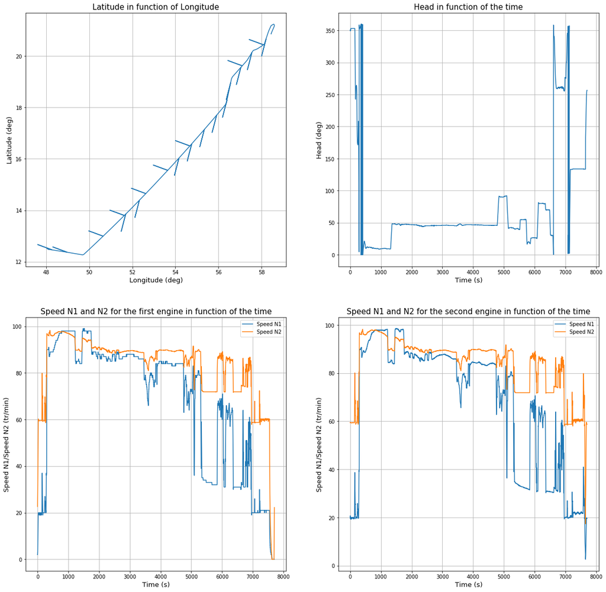

```python
import seaborn as sns
f = plt.figure(figsize=(20,20))
ax1 = f.add_subplot(2,2,1)
ax1.plot(flights1[0]['LATP_1'][3:], flights1[0]['LONP_1'][3:])
plt.title("Latitude in function of Longitude",fontsize=15)
plt.xlabel('Longitude (deg)', fontsize = 13)
plt.ylabel('Latitude (deg)', fontsize = 13)

ax1 = f.add_subplot(2,2,2)
ax1.plot(flights1[0]['TIME'], flights1[0]['HEAD'])
#ax1.plot(flights1[0]['TIME'], flights1[0]['LATP_1b'])
plt.title("Head in function of the time",fontsize=15)
plt.xlabel('Time (s)', fontsize = 13)
plt.ylabel('Head (deg)', fontsize = 13)


ax1 = f.add_subplot(2,2,3)
ax1.plot(flights1[0]['TIME'], flights1[0]['N11'])
ax1.plot(flights1[0]['TIME'], flights1[0]['N21'])
plt.title("Speed N1 and N2 for the first engine in function of the time",fontsize=15)
plt.xlabel('Time (s)', fontsize = 13)
plt.ylabel('Speed N1/Speed N2 (tr/min)', fontsize = 13)
plt.legend(["Speed N1","Speed N2"])


ax1 = f.add_subplot(2,2,4)
ax1.plot(flights1[0]['TIME'], flights1[0]['N12'])
ax1.plot(flights1[0]['TIME'], flights1[0]['N22'])
plt.legend(["Speed N1","Speed N2"])
plt.title("Speed N1 and N2 for the second engine in function of the time",fontsize=15)
plt.xlabel('Time (s)', fontsize = 13)
plt.ylabel('Speed N1/Speed N2 (tr/min)', fontsize = 13)
plt.show()
```

Then, we can see the `HEAD` value as a function of time. This relates to the angle the plane is taking, and we can see that we have errors (discontinuities) when the plane goes above 360 or below 0. This is due to the limited range (0,360) of the compass. We will take care of this later on.

Finally, we can see the N1 and N2 speeds of both engines. Our first thought when looking at the graph is that the left and right engines kind of follow the same evolution in speed. Moreover, we can see how N1 is much lower than N2 when decreasing in altitude (getting ready to land), when the plane is decreasing in speed (decreasing the engine's thrust, more than the actual decrease in speed). Finally, we can also see than N2 is much higher than N1 when taking off, which corresponds to what we read in the documentation.

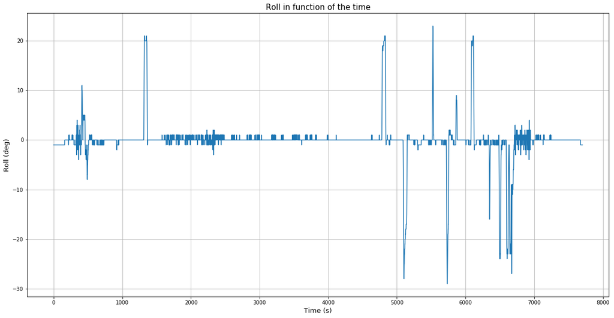

```python
f = plt.figure(figsize=(20,10))
plt.plot(flights1[0]['TIME'], flights1[0]['ROLL'])
#ax1.plot(flights1[0]['TIME'], flights1[0]['LATP_1'])
plt.title("Roll in function of the time",fontsize=15)
plt.xlabel('Time (s)', fontsize = 13)
plt.ylabel('Roll (deg)', fontsize = 13)
plt.show()
```

The overall shape corresponds to what we would exspect from the ROLL variable. The minimum and maximum values are lower than 30, which makes sense (otherwise the plane would lose too much in surface for its lift. More could also be dangerous for the passengers.

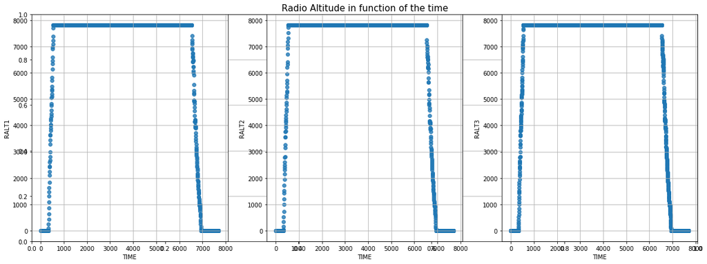

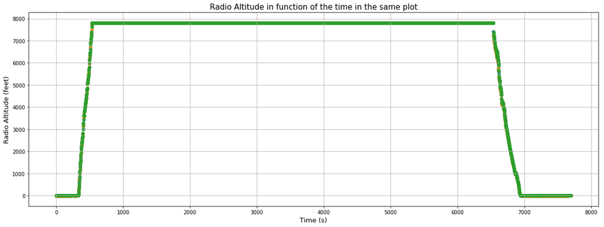

```python
import seaborn as sns
f = plt.figure(figsize=(20,7))
plt.title("Radio Altitude in function of the time",fontsize=15)
ax1 = f.add_subplot(1,3,1)
sns.regplot(flights1[0]['TIME'],flights1[0]['RALT1'], fit_reg=False, ax=ax1)
ax1 = f.add_subplot(1,3,2)
sns.regplot(flights1[0]['TIME'],flights1[0]['RALT2'], fit_reg=False, ax=ax1)
ax1 = f.add_subplot(1,3,3)
sns.regplot(flights1[0]['TIME'],flights1[0]['RALT3'], fit_reg=False, ax=ax1)
plt.show()
f = plt.figure(figsize=(20,7))
ax1 = f.add_subplot(1,1,1)
sns.regplot(flights1[0]['TIME'],flights1[0]['RALT1'], fit_reg=False, ax=ax1)
sns.regplot(flights1[0]['TIME'],flights1[0]['RALT2'], fit_reg=False, ax=ax1)
sns.regplot(flights1[0]['TIME'],flights1[0]['RALT3'], fit_reg=False, ax=ax1)
plt.title("Radio Altitude in function of the time in the same plot",fontsize=15)
plt.xlabel('Time (s)', fontsize = 13)
plt.ylabel('Radio Altitude (feet)', fontsize = 13)
plt.show()
```

All three plots follow the same trend, but we can see that some have more 'holes' (nan values) than some others: RALT3 seems to have more points than the two others. When putting all three together, we have something more continuous, which we could use later on. But we will also see how to take care of the fact that they do not have the same sampling rate (the reason why we have more points for RALT3).

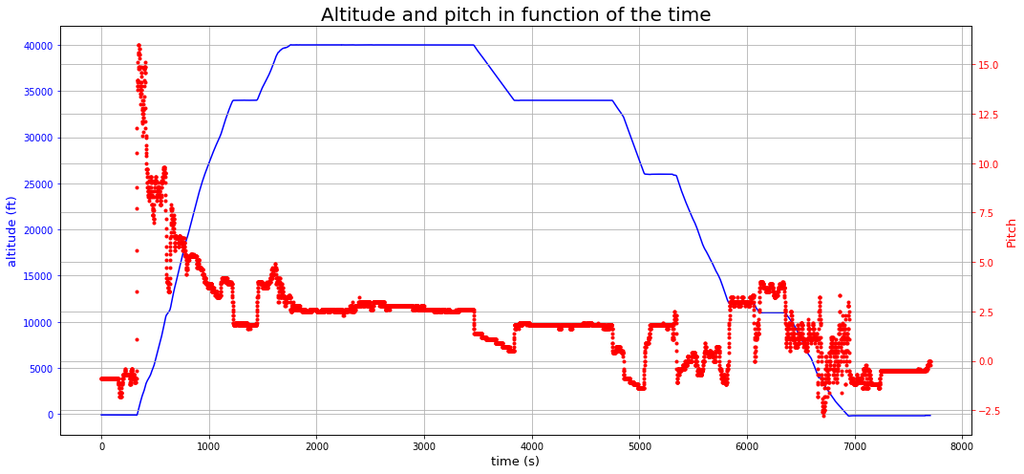

```python
fig, ax1 = plt.subplots(figsize=(15,7))
plt.title("Altitude and pitch in function of the time", fontsize = 20)
ax1.plot(flights1[0]['TIME'], flights1[0]['ALT_STD'], 'b-', label='Altitude (ft)')
ax1.set_xlabel('time (s)', fontsize = 13)
# Make the y-axis label, ticks and tick labels match the line color.
ax1.set_ylabel('altitude (ft)', color='b', fontsize = 13)
ax1.tick_params('y', colors='b')
ax2 = ax1.twinx()
ax2.plot(flights1[0]['TIME'], flights1[0]['PITCH'], 'r.', label='Pitch')
ax2.set_ylabel('Pitch', color='r', fontsize = 13)
ax2.tick_params('y', colors='r')
fig.tight_layout()
plt.show()
```

As expected, we have a correlation between the Pitch and the Altitude values. The Pitch increases a lot when taking off. But it does not decrease too much when preparing for landing since it is mostly the speed that will take care of descending the plane.

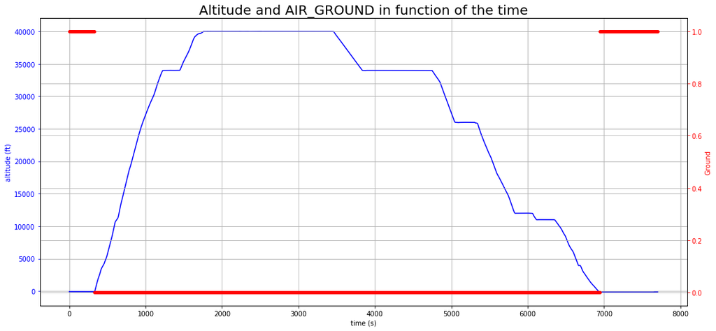

```python
fig, ax1 = plt.subplots(figsize=(15,7))
plt.title("Altitude and AIR_GROUND in function of the time", fontsize = 20)
ax1.plot(flights1[0]['TIME'], flights1[0]['ALT_STD'], 'b-')
ax1.set_xlabel('time (s)')
# Make the y-axis label, ticks and tick labels match the line color.
ax1.set_ylabel('altitude (ft)', color='b')
ax1.tick_params('y', colors='b')

ax2 = ax1.twinx()
ax2.plot(flights1[0]['TIME'], flights1[0]['AIR_GROUND'], 'r.')
ax2.set_ylabel('Ground', color='r')
ax2.tick_params('y', colors='r')

fig.tight_layout()
plt.show()
```

What we see here is that our two AIR_GROUND and ALT_STD columns corresond to each other and that we most likely do not have errors for those values.

```python
from mpl_toolkits.mplot3d import Axes3D
```

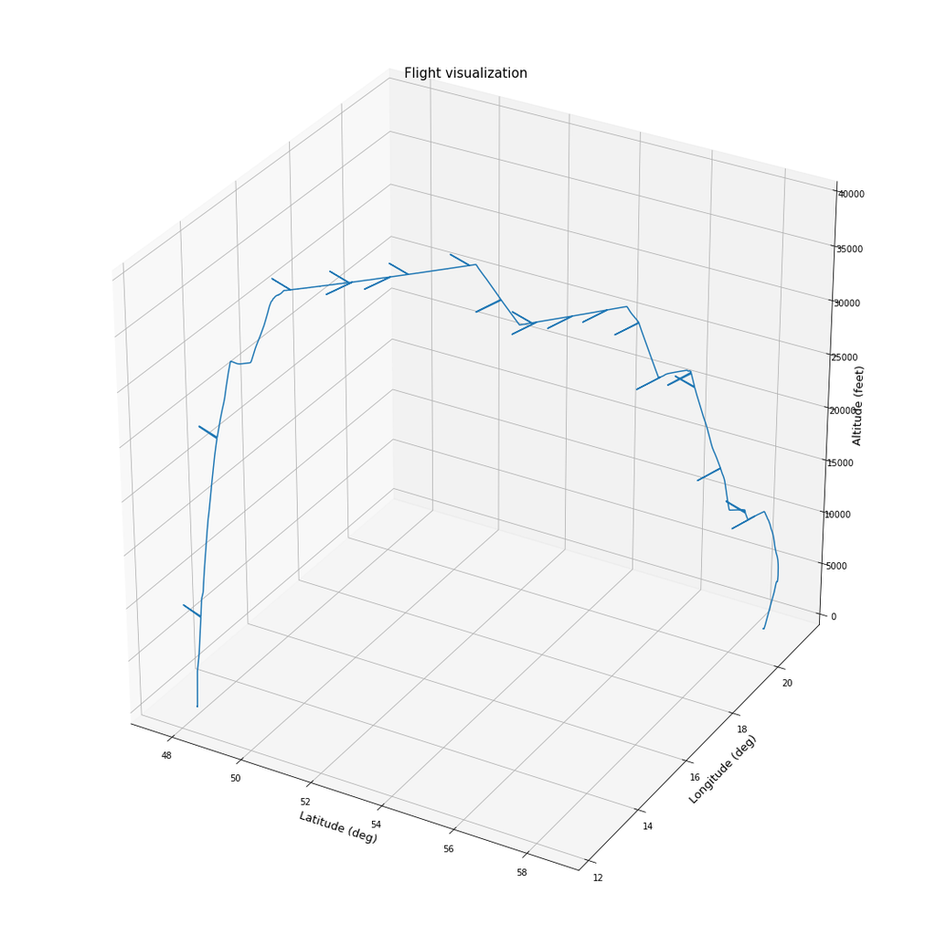

```python
fig = plt.figure(figsize=(15,15))
ax=fig.gca(projection='3d')
ax.plot(flights1[0]['LATP_1'][3:], flights1[0]['LONP_1'][3:], flights1[0]['ALT_STD'][3:])
plt.title("Flight visualization ",fontsize=15)
plt.xlabel('Latitude (deg)', fontsize = 13)
plt.ylabel('Longitude (deg)', fontsize = 13)
ax.set_zlabel('Altitude (feet)', fontsize = 13)

plt.tight_layout()
plt.show()
```

We present here an overview of the whole flight. We plotted the latitude and the longitude while adding the altitude. That way we can see the overall flight plan of the plane.

```python
#we calculate the percentage of missing values in the test set
test_missing_percent=((flights1[0].isnull().sum()/len(flights1[0]))*100).sort_values(ascending=False)
test_missing_percent.head(20)
```

```
RALT2         75.0
RALT1         75.0
RALT3         50.0
AIR_GROUND     0.0
N12            0.0
N22            0.0
N21            0.0
N11            0.0
ALT_STD        0.0
IAS            0.0
ROLL           0.0
PITCH          0.0
HEAD           0.0
LONP_1         0.0
LATP_1         0.0
TIME           0.0
dtype: float64
```

If it is interesting to see the variables for a given flight, it is more informative to view the set of values for all flights in order to understand what are the significant/normal values and what are those which are abnormal.

As we can see here (and from what we saw earlier), the radio altitude columns have some missing values, that we will need to take care of. We can also see here how RALT3 does not have the same sampling rate of the other two.

### Question 2 Visualize N21 variable for all flights

For the `N21` variable, for example, display all of the flights on the same figure. Use alpha parameter to add transparency to your plot. Is there any pattern? Comment the variabilities you observe.

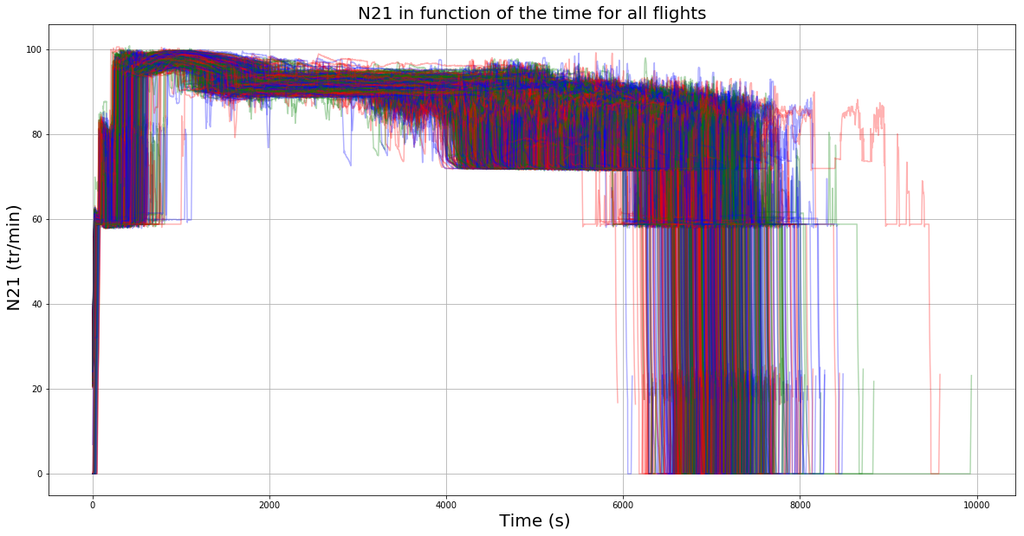

```python
plt.figure(figsize=(20,10))
plt.title("N21 in function of the time for all flights", fontsize = 20)
plt.xlabel(" Time (s)", fontsize = 20)
plt.ylabel(" N21 (tr/min)", fontsize = 20)
colors=['r', 'b', 'g']
for flightNbr in range(len(flights1)):
    plt.plot(flights1[flightNbr]['TIME'], flights1[flightNbr]['N21'], '{}-'.format(colors[flightNbr%3]), alpha=0.3)
plt.show()
```

We can see that all flights have overall the same 'procedure' for the management of their speed. The overall shape goes accordingly to the length of the flight (we can see a few flight that took longer) and but they overall have the same shape: they increase a lot for takeoff, then follow a constant speed when the plane is in the air during its normal flight time, then a slow decrease (with several steps) when preparing for landing.

Some variables must be analyzed together, such as latitude and longitude, otherwise the visualization information will be incomplete, we could be missing something.

### Question 3 Visualize latitude against longitude for all flights

Display the trajectories (`LONP_1`, `LATP_1`) of the first 20 flights, that is `flights1[:20]`. What do you see? Keep in mind that the data during the beginning of the recording may be abnormal. What insight do you lose when you plot `LONP_1` against `LATP_1` ?

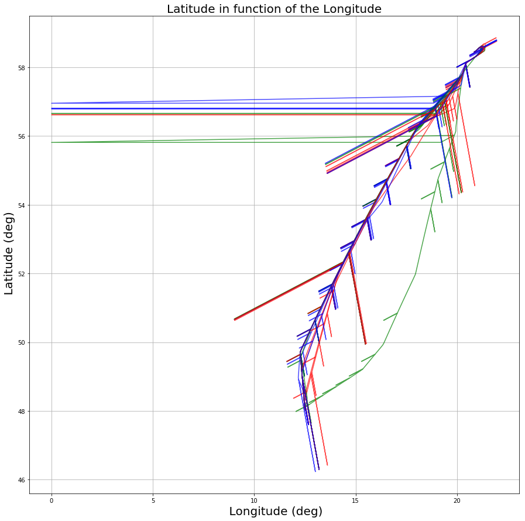

```python
plt.figure(figsize=(15,15))
plt.title("Latitude in function of the Longitude", fontsize = 20)
plt.ylabel(" Latitude (deg)", fontsize = 20)
plt.xlabel(" Longitude (deg)", fontsize = 20)
colors=['r', 'b', 'g']
for flightNbr in range(len(flights1[:20])):
    plt.plot(flights1[flightNbr]['LONP_1'][3:-2], flights1[flightNbr]['LATP_1'][3:-2], '{}-'.format(colors[flightNbr%3]), alpha=0.7)
plt.show()
```

We can see that all of our flights have the same paths (except one), and we can mostly see that there are a lot of outlier points (those little peaks that we can see). But what is more striking is that they have the same outliers.

Keep in mind that our goal is to understand the nature and the inherent problems of our data, and its features. Proceed with the visual analysis of the data, looking at different features.

### Question 4 Recap variables that require pre-processing

Based on your observations as for now, what are the variables requiring processing? For each of these variables, specify the necessary pre-processing required prior to perform data analysis.

- Latitude and Longiture: remove random outliers (+ first 3 points)
  - remove point if it is too far from average of previous and next point (and replace it by the average of the neighbor points)
- Head: remove discontinuities and take care of points at takeoff and landing
- Radar Altitude (1,2,3): take care of `nan` values and their sampling rate

It is important to undestand the links between variables, to understand how a system works.

### Question 5 Correlation between variables

Compute the correlation of each normalized variables with any others for one flight. Compute delay and max value for each pair of variables. What happens if you do not normalize ? What are the most correlated variables or group of variables ? Can you comment about the delay between variables ?

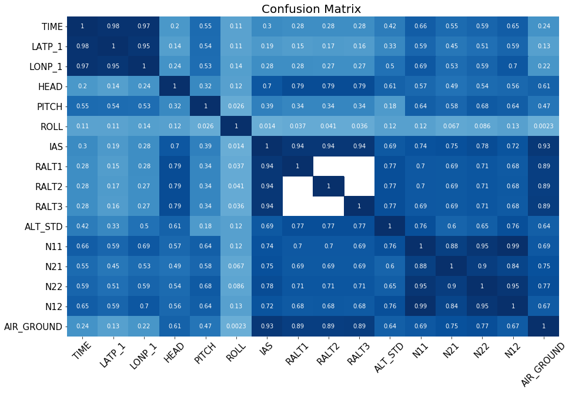

```python
plt.figure(figsize=(15,10))
corrMat = flights1[0].corr().abs()
cm = sns.heatmap(corrMat, center=0, cmap="Blues", annot =True, cbar = False )
plt.yticks(size = 15)
plt.xticks(rotation = 45, size= 15)
plt.title('Confusion Matrix ', fontsize = 20)
plt.show()
```

We decided here to use the Seaborn module to display the correlation map for all columns. We can see that the latitude and longitude are strongly correlated with the time (which is normal, the planes moves as the time goes by). We can also see that the AIR_GROUND value is strongly correlated to the IAS and the RALT{1,2,3}, which makes sense since all greatly increases when the plane is in the air. Moreover, we can see that the altitude is correlated to the engines (Nxx), which seems normal since they're the one in charging of making the plane fly. Finally, we can see that the ROLL variable is not strongly correlated with any other column.

```python
from scipy import signal
def correlation(x,y):
    all_correlations = scipy.correlate(x,y)
    maximum_correlation = np.max(all_correlations)
    delay = np.argmax(all_correlations)-x.shape[0]+1
    return maximum_correlation, delay
```

```python
for c, col in enumerate(flights1[125].columns):
    for sndCol in flights1[125].columns[c+1:]:
        print("Correl between {} and {}: {}".format(col, sndCol, correlation(flights1[125][col], flights1[125][sndCol])))
```

```
Correl between TIME and LATP_1: (1381819669.3315, -7019)
Correl between TIME and LONP_1: (452697798.4862, -7019)
Correl between TIME and HEAD: (2395369399.1400003, -7019)
Correl between TIME and PITCH: (48225311.9, -7019)
Correl between TIME and ROLL: (-10316897.0, -7019)
Correl between TIME and IAS: (5523506671.0, -7019)
Correl between TIME and RALT1: (nan, -7019)
Correl between TIME and RALT2: (nan, -7019)
Correl between TIME and RALT3: (nan, -7019)
Correl between TIME and ALT_STD: (505631956893.0, -7019)
Correl between TIME and N11: (1518758356.0, -7019)
Correl between TIME and N21: (2039522186.52, -7019)
Correl between TIME and N22: (1981621728.2799997, -7019)
Correl between TIME and N12: (1493765429.9, -7019)
Correl between TIME and AIR_GROUND: (2443090.0, -7019)
Correl between LATP_1 and LONP_1: (6337553.567547119, -7019)
Correl between LATP_1 and HEAD: (31796360.950548805, -7019)
Correl between LATP_1 and PITCH: (916310.14741, -7019)
Correl between LATP_1 and ROLL: (-36847.928599999985, -7019)
Correl between LATP_1 and IAS: (86941380.83929999, -7019)
Correl between LATP_1 and RALT1: (nan, -7019)
Correl between LATP_1 and RALT2: (nan, -7019)
Correl between LATP_1 and RALT3: (nan, -7019)
Correl between LATP_1 and ALT_STD: (8675138745.8564, -7019)
Correl between LATP_1 and N11: (26239963.3764, -7019)
Correl between LATP_1 and N21: (32389791.074187, -7019)
Correl between LATP_1 and N22: (31921956.620805003, -7019)
Correl between LATP_1 and N12: (26028768.398153003, -7019)
Correl between LATP_1 and AIR_GROUND: (37887.0081, -7019)
Correl between LONP_1 and HEAD: (10214335.7829386, -7019)
Correl between LONP_1 and PITCH: (266945.3226, -7019)
Correl between LONP_1 and ROLL: (-22579.184500000007, -7019)
Correl between LONP_1 and IAS: (26353551.8481, -7019)
Correl between LONP_1 and RALT1: (nan, -7019)
Correl between LONP_1 and RALT2: (nan, -7019)
Correl between LONP_1 and RALT3: (nan, -7019)
Correl between LONP_1 and ALT_STD: (2538763874.2315, -7019)
Correl between LONP_1 and N11: (7742828.4745, -7019)
Correl between LONP_1 and N21: (9804719.713493, -7019)
Correl between LONP_1 and N22: (9638308.983424, -7019)
```

[output cut: 65 more lines]

```
Correl between ALT_STD and N11: (13254708013.0, -7019)
Correl between ALT_STD and N21: (14580767161.500002, -7019)
Correl between ALT_STD and N22: (14584287286.359999, -7019)
Correl between ALT_STD and N12: (13242879724.78, -7019)
Correl between ALT_STD and AIR_GROUND: (128799.0, -7019)
Correl between N11 and N21: (44370096.359999985, -7019)
Correl between N11 and N22: (44167558.739999995, -7019)
Correl between N11 and N12: (39555644.78999999, -7019)
Correl between N11 and AIR_GROUND: (18206.0, -7019)
Correl between N21 and N22: (52099866.94399999, -7019)
Correl between N21 and N12: (44112895.48309999, -7019)
Correl between N21 and AIR_GROUND: (45097.740000000005, -7019)
Correl between N22 and N12: (44119809.870699994, -7019)
Correl between N22 and AIR_GROUND: (37012.46, -7019)
Correl between N12 and AIR_GROUND: (15102.34, -7019)
```

## Pre-processing

Data pre-processing is essential, in order to separate the errors due to measurement from "normal" data variability, which is representative of the phenomenon that interests us.

### Question 6 Smooth and filter out abnormal data in trajectories (LATP_1 and LONP_1)

Filter the flight trajectories (`LATP_1` and `LONP_1` variables). You can focus on the first 20 flights, that is `flights1[:20]`. Display the trajectories before and after smoothing.

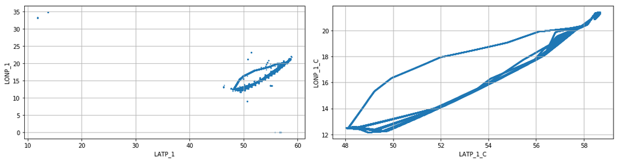

```python
# this is a template code, fill in the blanks, or use your own code

# Only work with the first few flights
fs = flights1[:20]

# Set up the figure to plot the trajectories before (ax0) and after smoothing (ax1)
fig, axarr = plt.subplots(1, 2)
fig.set_figwidth(15)
ax0, ax1 = axarr

for f in fs:
    f["LATP_1_C"] = f.LATP_1.rolling(window=10, center=True).median() # FILL IN THE BLANKS
    f["LONP_1_C"] = f.LONP_1.rolling(window=10, center=True).median() # FILL IN THE BLANKS

for f in fs:
    f.plot(kind="scatter", x="LATP_1", y="LONP_1", s=1, ax=ax0) # plot raw trajectory
    f.plot(kind="scatter", x="LATP_1_C", y="LONP_1_C", s=1, ax=ax1) # plot smoothed trajectory
fig.tight_layout()
```

We were able to take out all of the outliers and smooth out our data. We now have a clearer view of the flights.

We can aslo plot the 3D representation (with the altitude) to see the whole flight plan (graph below). The overall view is clearer and more realistic.

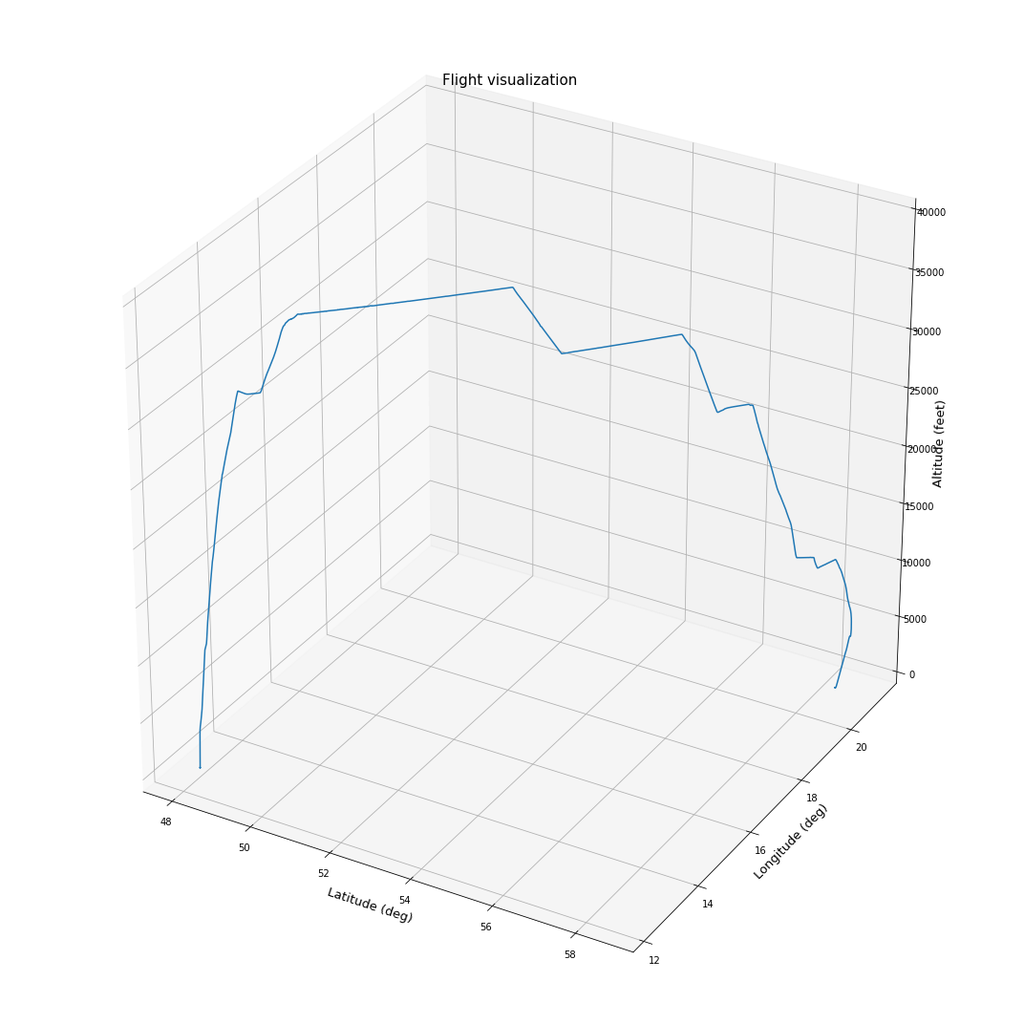

```python
fig = plt.figure(figsize=(15,15))
ax=fig.gca(projection='3d')
ax.plot(flights1[0]['LATP_1_C'][3:], flights1[0]['LONP_1_C'][3:], flights1[0]['ALT_STD'][3:])
plt.title("Flight visualization ",fontsize=15)
plt.xlabel('Latitude (deg)', fontsize = 13)
plt.ylabel('Longitude (deg)', fontsize = 13)
ax.set_zlabel('Altitude (feet)', fontsize = 13)

plt.tight_layout()
plt.show()
```

### Question 7 Pre-process HEAD, get rid off discontinuities

Angles are special variables because they "cycle" over their range of values. The `HEAD` variable shows artificial discontinuities: your goal is to eliminate (filter out) such discontinuities. The angle may no longer be between 0 and 360 degrees after the transformation but it will come very handy for some analysis later. Display the data before and after transformation. You can focus on one flight, for example `flights1[0]`.

```python
adding=False; substracting=False; points=[]
for p, point in enumerate(flights1[0]['HEAD'][:-1]):
    if flights1[0]['HEAD'][p+1] - point > 200 and not substracting:
        substracting=True
    elif flights1[0]['HEAD'][p+1] - point < -200 and substracting:
        substracting = False
        point-=360
    elif flights1[0]['HEAD'][p+1] - point > 200 and adding:
        adding = False
        point+=360
    elif flights1[0]['HEAD'][p+1] - point < -200 and not adding: adding = True

    if substracting: point-=360
    if adding: point+=360
    points.append(point)
points.append(flights1[0]['HEAD'][-1])
flights1[0]['HEAD_C'] = points

flights1[0]["HEAD_C"] = flights1[0].HEAD_C.rolling(window=15, center=True).median() # FILL IN THE BLANKS
```

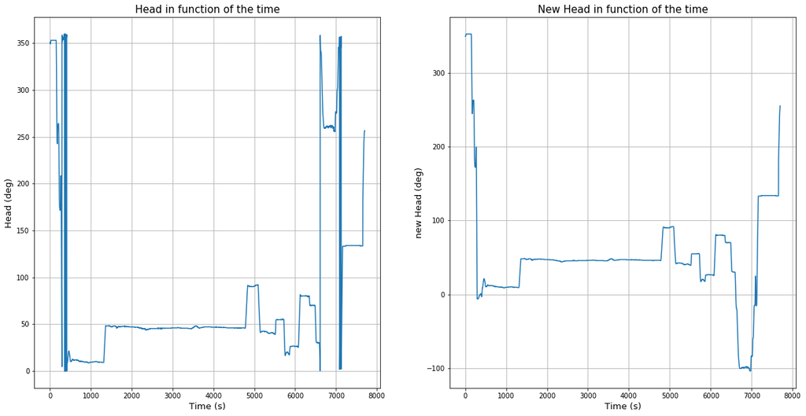

```python
f = plt.figure(figsize=(20,10))
ax1 = f.add_subplot(1,2,1)
ax1.plot(flights1[0]['TIME'], flights1[0]['HEAD'])
#ax1.plot(flights1[0]['TIME'], flights1[0]['LATP_1'])
plt.title("Head in function of the time",fontsize=15)
plt.xlabel('Time (s)', fontsize = 13)
plt.ylabel('Head (deg)', fontsize = 13)

ax1 = f.add_subplot(1,2,2)
ax1.plot(flights1[0]['TIME'], flights1[0]['HEAD_C'])
#ax1.plot(flights1[0]['TIME'], flights1[0]['LATP_1'])
plt.title("New Head in function of the time",fontsize=15)
plt.xlabel('Time (s)', fontsize = 13)
plt.ylabel('new Head (deg)', fontsize = 13)
plt.show()
```

We decided study our data points by quantifying discontinuites and increasing the range of values that our HEAD values could take so that the overall dataset could better fit into it. To do so, we study each point compared to the following to see if there is a discontinuity. If so, we add or substract 360 degrees to make it continuous. We decided to smooth it out a little bit at the end to remove some outliers (corresponding to the old discontinuities). The finale graph shows the HEAD values without any major discontinuity, showing how the plane evolved throughout its flight.

### Question 8 All data on the same time base

When we make an analysis, it is important to have the maximum of information. However, for any flight, you can see that there is three RALT (`RALT1`, `RALT2`, `RALT3`). They are not at the same sampling rate. Use interpolation on one flight, for example `flights1[0]`,to have them at the same sampling rate of 1Hz. Then, merge your results. Can you comment on the method you used ?

```python
from scipy import interpolate
for s in [1,2,3]:
    flights1[0]['RALT{}_I'.format(s)] = flights1[0]['RALT{}'.format(s)].interpolate(method='linear', limit_direction='both')
```

```python
display(flights1[0][['RALT1','RALT2','RALT3','RALT1_I','RALT2_I','RALT3_I']].head(20))
```

|  | RALT1 | RALT2 | RALT3 | RALT1_I | RALT2_I | RALT3_I |
| --- | --- | --- | --- | --- | --- | --- |
| 2018-06-01 00:00:00 | NaN | NaN | -4.0 | -4.0 | -5.00 | -4.0 |
| 2018-06-01 00:00:01 | -4.0 | NaN | NaN | -4.0 | -5.00 | -4.0 |
| 2018-06-01 00:00:02 | NaN | NaN | -4.0 | -4.0 | -5.00 | -4.0 |
| 2018-06-01 00:00:03 | NaN | -5.0 | NaN | -4.0 | -5.00 | -4.0 |
| 2018-06-01 00:00:04 | NaN | NaN | -4.0 | -4.0 | -5.00 | -4.0 |
| 2018-06-01 00:00:05 | -4.0 | NaN | NaN | -4.0 | -5.00 | -4.0 |
| 2018-06-01 00:00:06 | NaN | NaN | -4.0 | -4.0 | -5.00 | -4.0 |
| 2018-06-01 00:00:07 | NaN | -5.0 | NaN | -4.0 | -5.00 | -4.0 |
| 2018-06-01 00:00:08 | NaN | NaN | -4.0 | -4.0 | -5.00 | -4.0 |
| 2018-06-01 00:00:09 | -4.0 | NaN | NaN | -4.0 | -5.00 | -4.0 |
| 2018-06-01 00:00:10 | NaN | NaN | -4.0 | -4.0 | -5.00 | -4.0 |
| 2018-06-01 00:00:11 | NaN | -5.0 | NaN | -4.0 | -5.00 | -4.0 |
| 2018-06-01 00:00:12 | NaN | NaN | -4.0 | -4.0 | -4.75 | -4.0 |
| 2018-06-01 00:00:13 | -4.0 | NaN | NaN | -4.0 | -4.50 | -4.0 |
| 2018-06-01 00:00:14 | NaN | NaN | -4.0 | -4.0 | -4.25 | -4.0 |
| 2018-06-01 00:00:15 | NaN | -4.0 | NaN | -4.0 | -4.00 | -4.0 |
| 2018-06-01 00:00:16 | NaN | NaN | -4.0 | -4.0 | -4.00 | -4.0 |
| 2018-06-01 00:00:17 | -4.0 | NaN | NaN | -4.0 | -4.00 | -4.0 |
| 2018-06-01 00:00:18 | NaN | NaN | -4.0 | -4.0 | -4.00 | -4.0 |
| 2018-06-01 00:00:19 | NaN | -4.0 | NaN | -4.0 | -4.00 | -4.0 |

# Part 2: Analysis

We now turn to the data analysis task. In this part, we will use a **clean** dataset, which has been prepared for you; nevertheless, the functions you developed in the first part of the notebook can still be used to visualize and inspect the new data. Next, we display the schema of the new dataset you will use:

| var | description |
| --- | --- |
| TIME | elapsed seconds |
| **LATP_C** | **Latitude (°), Corrected** |
| **LONP_C** | **Longitude (°), Corrected** |
| **RALT_F** | **Radio Altitude (feet), Fusioned** |
| **ALT_STD_C** | **Relative Altitude (feet), Corrected** |
| **HEAD_C** | **head (°), Corrected** |
| **HEAD_TRUE** | **head (°), without discontinuities** |
| **PITCH_C** | **pitch (°), Corrected** |
| **ROLL_C** | **roll (°), Corrected** |
| **IAS_C** | **Indicated Air Speed (m/s), Corrected** |
| N11 | speed N1 of the first engine (% of tr/min) |
| N21 | speed N2 of the first engine (% of tr/min) |
| N12 | speed N1 of the second engine (% of tr/min) |
| N22 | speed N2 of the second engine (% of tr/min) |
| AIR_GROUND | status in the air (Boolean) |

Execute the cell below to load the data for part 2

```python
num_flights = 780
flights2 = load_data_from_directory(BASE_DIR + "part2/flights/", num_flights)
for f in flights2:
    l = len(f)
    new_idx = pd.date_range(start=pd.Timestamp("now").date(), periods=l, freq="S")
    f.set_index(new_idx, inplace=True)
```

```
There are 780 files in total
We process 780 files
```

In this part, we will try to modelize a time series with simple models. In particular, we will look at the landing, and the N1 variable.

First, look at the variables for the flight 0, by executing the following code.

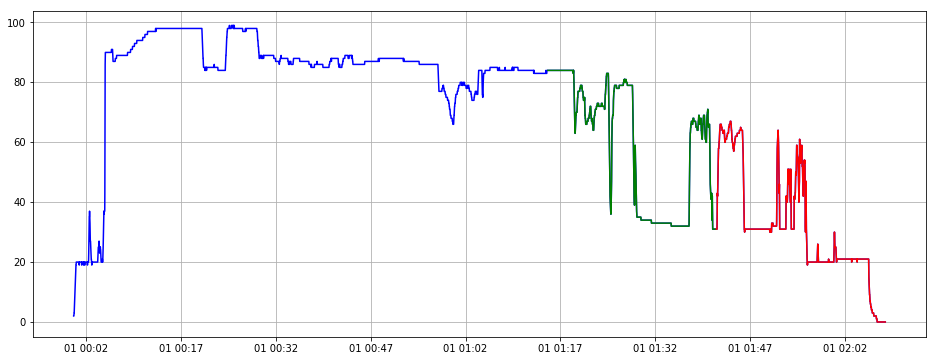

```python
plt.figure(figsize=(16,6))
plt.plot(flights2[0]['N11'], 'b')
index_start = 4500
tomodel = flights2[0]['N11'][index_start:index_start+1600]
topredict = flights2[0]['N11'][index_start+1600:index_start+3600]
plt.plot(tomodel, 'g')
plt.plot(topredict, 'r')
plt.show()
```

### Question 9 Modelization of time series

Is it stationary ? The augmented Dickey-Fuller test is a popular test to test the null hypothesis that a time series sample is non-stationary. Use this test to confirm what you observed.

```python
import scipy.stats.stats as stats
from statsmodels.tsa.stattools import adfuller

DFtest_brut = adfuller(flights2[0]['N11'])[1]

print('Augmented D-F test before detrending:')
print('p-value = ' + str(DFtest_brut))
```

```
Augmented D-F test before detrending:
p-value = 0.3653398330963018
```

By looking at the graph from the previous question, we can assume that our data is non-stationary, because the first part (increasing slope) is not the same as the decreasing one (when the plane prepares to land). The descent is much 'slower' than the climb. So we can already guess that our mean and variance are not the same throughout the dataset.

Our p-value is quite high, so our data fails to reject the **null hypothesis**: the data has a unit root ans is **non-stationary**.

### Question 10 Modelization of time series

We may want to detrend the time serie. Fit a polynom or order 3 to the sequence `tomodel`, remove the trend and look at the Dickey-Fuller test again. Should you have used an higher degree polynomial? What would be the issue of a high degree polynomial when trying to do prediction of future sample?

```python
a = PolynomialFeatures(3)
model = Pipeline([('poly',a)])#, ('Linear_reg', LinearRegression())])
model.fit_transform(np.array(tomodel.index).reshape(-1,1),tomodel).sum(axis=1)
```

```
array([3.56625921e+54, 3.56625921e+54, 3.56625922e+54, ...,
       3.56627039e+54, 3.56627040e+54, 3.56627040e+54])
```

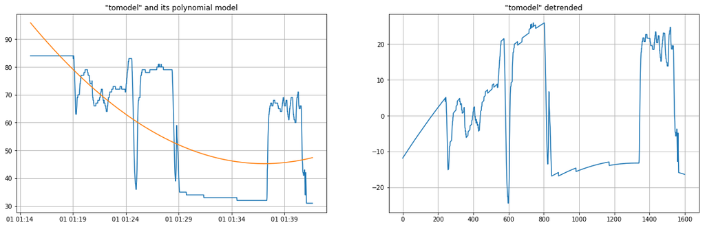

```
Augmented D-F test after detrending:
p-value = 0.0808838062013284
```

```python
from sklearn.preprocessing import PolynomialFeatures
from sklearn.linear_model import LinearRegression
from sklearn.pipeline import Pipeline

f = plt.figure(figsize=(20,6))

a = PolynomialFeatures(3)
model = Pipeline([('poly',a), ('Linear_reg', LinearRegression(normalize=True))])
model.fit(np.array(tomodel.index).reshape(-1,1),tomodel)#.reshape(-1,1))

trend_model = model.predict(np.array(tomodel.index).reshape(-1,1))

#plotting the trend
ax1 = f.add_subplot(1,2,1)
ax1.plot(tomodel)
ax1.plot(np.array(tomodel.index),trend_model)
ax1.set_title('"tomodel" and its polynomial model')


#detrended
detrended = [ tomodel[i] - trend_model[i] for i in range(len(trend_model))]

#plotting the trend
ax2 = f.add_subplot(1,2,2)
ax2.plot(detrended)
ax2.set_title('"tomodel" detrended')
plt.show()


DFtest_corrected = (adfuller(detrended)[1])
print('Augmented D-F test after detrending:')
print('p-value = ' + str(DFtest_corrected))
```

We computed the overall trend for our model data, aiming at removing it afterwards to make it *more stationary*. As we can see on the second graph, the time series has been **detrended** and so is looks **stationary**.

Then, we also computed the new p-value of the Dickey-Fuller test, for the *detrended dataset*. We got 0.081, which is better than what we had before, but which still indicates **non-stationarity**. We still cannot reject the **null hypothesis**.

What we can see here is that our model is too weak to really fit our dataset. The risk with what we got here is **overfitting**, that is getting too close to our dataset and therefore too far from the future predictions. If we increase the degree of the polynom, we would probably increase the overfitting since we will get even close to our training dataset.

### Question 11 Prediction using polynomial

We want to predict what will be our next N11 in the next time steps. Use the polynom to predict the end of `tomodel`. Compare to `topredict`. What can you say ? What could you do to improve your prediction ?

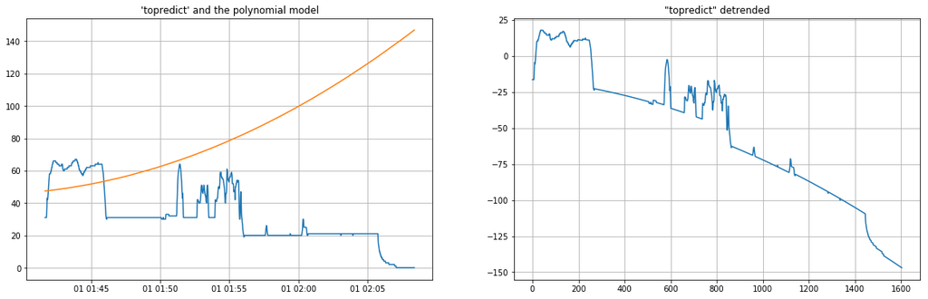

```
Augmented D-F test after detrending:
p-value = 0.9607386099403264
```

```python
f = plt.figure(figsize=(20,6))

trend_predict = model.predict(np.array(topredict.index).reshape(-1,1))

#plotting the trend
ax1 = f.add_subplot(1,2,1)
ax1.plot(topredict)
ax1.plot(np.array(topredict.index),trend_predict)
ax1.set_title("'topredict' and the polynomial model")

#detrended
detrended = [ topredict[i] - trend_predict[i] for i in range(len(trend_predict))]

#plotting the trend
ax2 = f.add_subplot(1,2,2)
ax2.plot(detrended)
ax2.set_title('"topredict" detrended')
plt.show()

DFtest_corrected = (adfuller(detrended)[1])
print('Augmented D-F test after detrending:')
print('p-value = ' + str(DFtest_corrected))
```

Using the predictions from the previous question, we tried to predict the data from `topredict`. But as we were expecting, we overfitted a lot.

We also computed the new p-value of the Dickey-Fuller test, for the *detrended dataset*. We got 0.961, which proves how non effective our detrending was with our polynomial model.

We will now see if we can model the time series using auto-regressive / moving-average models. The **ARIMA** technique (Auto-Regressive Integrated Moving Average) allows modeling and forecasting of time series. The parameters of an ARIMA model are often noted (p,d,q) where:

- p is the number of auto-regressive terms (AR), e.g. if p=3, x(t) will be determined from x(t-1), x(t-2) and x(t-3)
- d is the number of differences to take before obtaining a stationary time series
- q is the number of moving average (MA) terms.

Autocorrelation (ACF) and partial autocorrelation (PACF) plots are a usefull tool to identify the values for *p* and *q*. The autocorrelation describes the correlation of observations with observations at previous time steps (or lags). Partial autocorrelation does the same thing but for lag *k* removes the effect of correlations due to the terms at shorter lags.

Plot the ACF and PACF of the time series.

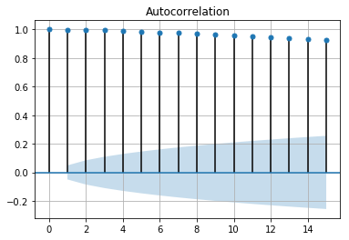

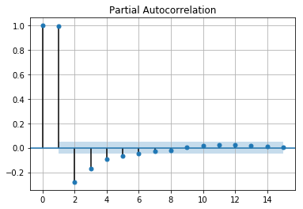

```python
from statsmodels.graphics.tsaplots import plot_acf
from statsmodels.graphics.tsaplots import plot_pacf
plot_acf(tomodel,lags=15)
plt.show()
plot_pacf(tomodel,lags=15)
plt.show()
```

On thoses plots you can observe blue shaded regions, those are confidence interevals (set to a 95% default value). Values of ACF or PACF outside of this region are likely to be correlations and not noise.

Observe the shape of the two plots:

[output not shown]

This is the sign of an auto-regressive AR(5) process.

To sum up:

```
the signal is not stationary, so we can try to have d=1
it seems to be an AR(5) process so p=5 and q=0
```

### Question 12 Prediction using ARIMA

Now, train an ARIMA(5,1,0) model on the data, and then, use it to predict the next steps of `tomodel`. Compare it to `topredict`

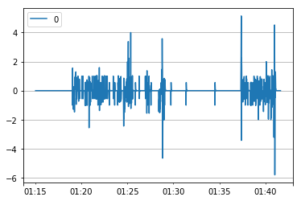

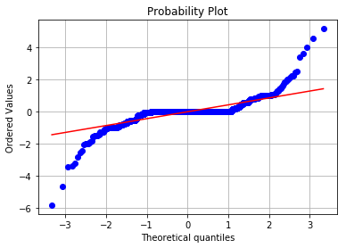

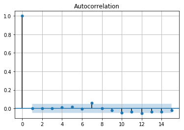

```
                 0
count  1599.000000
mean     -0.007839
std       0.552096
min      -5.802284
25%       0.000000
50%       0.000000
75%       0.000000
max       5.141680
```

```python
from statsmodels.tsa.arima_model import ARIMA
from scipy.stats import probplot

ARmodel = ARIMA(tomodel,order=(5,1,0))
ARfitres = ARmodel.fit(trend='nc')


residuals = pd.DataFrame(ARfitres.resid)
residuals.plot()
plt.show()

probplot(ARfitres.resid, dist='norm',plot=plt)
plt.show()

plot_acf(ARfitres.resid,lags=15)
plt.show()

print(residuals.describe())
```

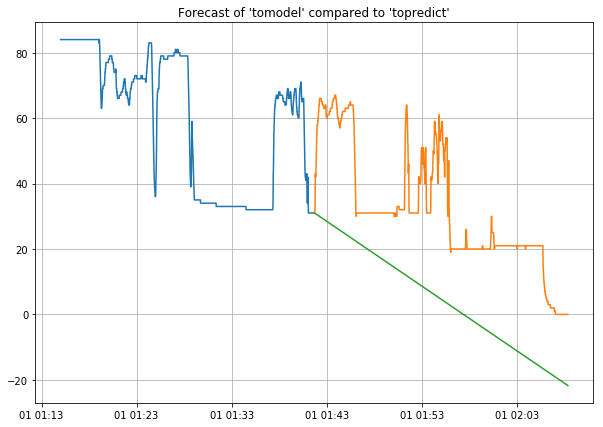

```python
model = ARIMA(tomodel,order=(5,1,0))
model_res = model.fit(disp=0)
newval = model_res.forecast(len(topredict))[0]

X = tomodel.index.tolist() + topredict.index.tolist()
plt.figure(figsize=(10,7))
plt.plot(X[:len(tomodel)],tomodel)
plt.plot(X[len(tomodel):],topredict)
plt.plot(X[len(tomodel):],newval)
plt.title("Forecast of 'tomodel' compared to 'topredict'")
plt.show()
```

Another thing we can try is to train ARIMA on the polynomial model we found earlier.

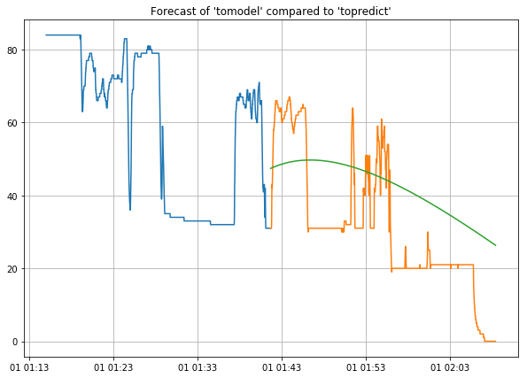

```python
model = ARIMA(trend_model,order=(5,1,0))
model_res = model.fit(disp=0)
newval_trend = model_res.forecast(len(topredict))[0]

X = tomodel.index.tolist() + topredict.index.tolist()
plt.figure(figsize=(10,7))
plt.plot(X[:len(tomodel)],tomodel)
plt.plot(X[len(tomodel):],topredict)
plt.plot(X[len(tomodel):],newval_trend)
plt.title("Forecast of 'tomodel' compared to 'topredict'")
plt.show()
```

This looks actually very promising. We lost the overall trend that we had before but our MSE should actually be lower.

We tried two models. We now want to compare them in a more scientific way, to select the best model.

### Question 13 Compare models

Compute the mean squared error to compare the two models. Comment on the results, then comment on the two approaches.

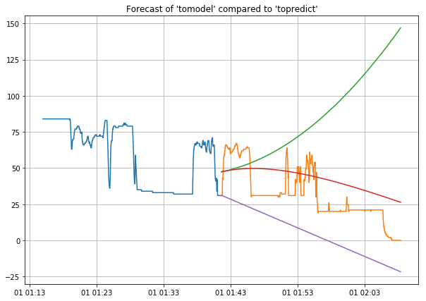

```python
plt.figure(figsize=(10,7))
plt.plot(X[:len(tomodel)],tomodel)
plt.plot(X[len(tomodel):],topredict)
plt.plot(X[len(tomodel):],trend)
plt.plot(X[len(tomodel):],newval_trend)
plt.plot(X[len(tomodel):],newval)
plt.title("Forecast of 'tomodel' compared to 'topredict'")
plt.show()
```

```python
from sklearn.metrics import mean_squared_error as mse
```

```python
print("MSE Polynomial: %.3f" % mse(trend, topredict.values))
print("MSE ARIMA: %.3f" % mse(newval, topredict.values))
print("MSE ARIMA w/ trend: %.3f" % mse(newval_trend, topredict.values))
```

```
MSE Polynomial: 4857.005
MSE ARIMA: 824.578
MSE ARIMA w/ trend: 291.039
```

As expected, the ARIMA model does much better than the polynomial one (which was overfitting). We also tried ARIMA in the polymial model, which does suprisingly well compared to the others (which we were expecting from the graphs).

To improve our models, we could try to find more exact parameters, or try different models.